# dplyr

Etienne Low-Décarie

### dplyr and plyr

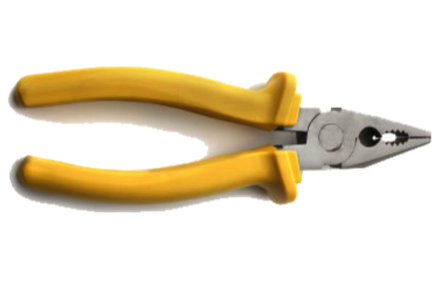

### Split-Apply-Combine

- Equivalent
  - SQL GROUP BY
  - Pivot Tables (Excel, SPSS, …)

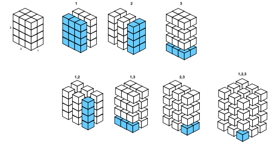

- Split
  - Define a subset of your data
- Apply
  - Do anything to this subset
  - calculation, modeling, simulations, plotting
- Combine
- Repeat this for all subsets
  - collect the results

### History and use

- plyr
  - any input, any output
    - to load a list of files
    - to produce plots
  - slow and complicated
- dplyr
  - data.frame in/data.frame out
  - faster
  - Details:
  - introducing chaining to R
  - remote database integration

### Conflict between plyr and dplyr

`plyr` and `dplyr` do not play nice together  
Always load `dplyr` last  
Be careful of packages that load `plyr`

```r
require(plyr)
require(dplyr)
```

you can also use `dplyr:::` to ensure functions are called from dplyr

[issue](https://github.com/hadley/dplyr/issues/347)

### dplyr

Vignette https://cran.rstudio.com/web/packages/dplyr/vignettes/introduction.html

Cheatsheet https://www.rstudio.com/wp-content/uploads/2015/02/data-wrangling-cheatsheet.pdf

### Grouping

**Split** -Apply-Combine

- `group_by()`

### Group data

```r
if(!require(dplyr)){install.packages("dplyr")}
require(dplyr)
CO2_by_Plant_Type_Treatment <- group_by(CO2,
                                        Plant,
                                        Type,
                                        Treatment)
```

### group data

`group_by` implies `tbl_df` `tbl_df` wraps a `data.frame`

```r
print(CO2_by_Plant_Type_Treatment)
```

```
Source: local data frame [84 x 5]
Groups: Plant, Type, Treatment [12]

    Plant   Type  Treatment  conc uptake
   (fctr) (fctr)     (fctr) (dbl)  (dbl)
1     Qn1 Quebec nonchilled    95   16.0
2     Qn1 Quebec nonchilled   175   30.4
3     Qn1 Quebec nonchilled   250   34.8
4     Qn1 Quebec nonchilled   350   37.2
5     Qn1 Quebec nonchilled   500   35.3
6     Qn1 Quebec nonchilled   675   39.2
7     Qn1 Quebec nonchilled  1000   39.7
8     Qn2 Quebec nonchilled    95   13.6
9     Qn2 Quebec nonchilled   175   27.3
10    Qn2 Quebec nonchilled   250   37.1
..    ...    ...        ...   ...    ...
```

```r
class(CO2_by_Plant_Type_Treatment)
```

```
[1] "grouped_df" "tbl_df"     "tbl"        "data.frame"
```

### group data

**Caution when working with functions that expect a `data.frame`**

```r
class(CO2_by_Plant_Type_Treatment)
```

```
[1] "grouped_df" "tbl_df"     "tbl"        "data.frame"
```

```r
head(as.data.frame(CO2_by_Plant_Type_Treatment))
```

```
  Plant   Type  Treatment conc uptake
1   Qn1 Quebec nonchilled   95   16.0
2   Qn1 Quebec nonchilled  175   30.4
3   Qn1 Quebec nonchilled  250   34.8
4   Qn1 Quebec nonchilled  350   37.2
5   Qn1 Quebec nonchilled  500   35.3
6   Qn1 Quebec nonchilled  675   39.2
```

### Apply verbes

Split-**Apply-Combine**

- `mutate`

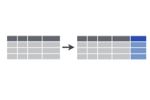

- `summarise`

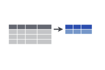

### Summarize grouped data

Summarize by extracting maximum uptake per plant

```r
CO2_max_per_plant <- dplyr:::summarise(CO2_by_Plant_Type_Treatment,
                               max_uptake=max(uptake))
print(CO2_max_per_plant)
```

```
Source: local data frame [12 x 4]
Groups: Plant, Type [?]

    Plant        Type  Treatment max_uptake
   (fctr)      (fctr)     (fctr)      (dbl)
1     Qn1      Quebec nonchilled       39.7
2     Qn2      Quebec nonchilled       44.3
3     Qn3      Quebec nonchilled       45.5
4     Qc1      Quebec    chilled       38.7
5     Qc3      Quebec    chilled       41.4
6     Qc2      Quebec    chilled       42.4
7     Mn3 Mississippi nonchilled       28.5
8     Mn2 Mississippi nonchilled       32.4
9     Mn1 Mississippi nonchilled       35.5
10    Mc2 Mississippi    chilled       14.4
11    Mc3 Mississippi    chilled       19.9
12    Mc1 Mississippi    chilled       22.2
```

### Plot summarized data

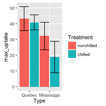

```r
dodge <- position_dodge(1)

p <- ggplot(data=CO2_max_per_plant,
           aes(x=Type,
           y=max_uptake,
           fill=Treatment))+
           geom_bar(stat="summary",
           fun.y=mean,
           position=dodge)+
  stat_summary(fun.data="mean_cl_normal",
               geom="errorbar",
               position=dodge)
```

### Create a beautiful table of summarized data

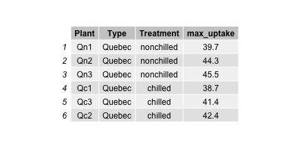

```r
if(!require(gridExtra)){install.packages("gridExtra")}
require(gridExtra)
grid.newpage()
grid.table(head(data.frame(CO2_max_per_plant)))
```

### Exercise 1

- Calculate the mean for each species value for each dimension of sepals and petals in the `iris` data set
- Produce an elegant table

### dplyr mutate data

Calculate deviation from the mean uptake for each plant

```r
CO2_with_deviation <- mutate(CO2_by_Plant_Type_Treatment,
                               deviation_from_mean=uptake-mean(uptake))
```

### Plot mutated data

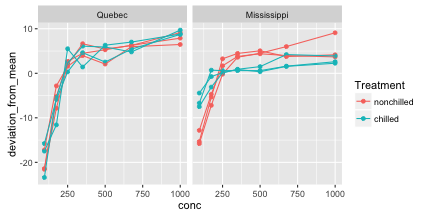

```r
CO2.plot <- qplot(data = CO2_with_deviation,
                  x = conc,
                  y = deviation_from_mean,
                  colour = Treatment) +
  facet_grid(.~Type)+
  geom_line(aes(group = Plant))
print(CO2.plot)
```

### Writing your own functions

Calculate the slope and intercept for each plant

```r
intercept_slope <- function(conc, uptake){
  fit <- lm(uptake~conc)
  coefficients <- coef(fit)
  return(data.frame(intercept=coefficients[1],
                    slope=coefficients[2]))
}
```

note: there is now a better way to do this using require(broom)

### Using your new function with dplyr

```r
CO2_fit <- summarise(CO2_by_Plant_Type_Treatment,
                     intercept=intercept_slope(conc, uptake)$intercept,
                     slope=intercept_slope(conc, uptake)$slope)
```

### Plot the results of your new function

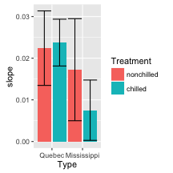

```r
dodge <- position_dodge(1)
p <- ggplot(data=CO2_fit,aes(x=Type,
           y=slope,
           fill=Treatment))+
           geom_bar(stat="summary",
           fun.y=mean,
           position=dodge)+
  stat_summary(fun.data="mean_cl_normal",
               geom="errorbar",
               position=dodge)
```

### Exercise 2

- Use the [exercise_data_temp_par.csv](https://github.com/low-decarie/Data_wrangling_and_plotting/tree/master/Data) file
- Calculate the deviations from the annual means
- Calculate the annual absolute integrated anomaly

\[ \sum_{i=January}^{i=December}\left\lvert x_i- \bar x _{i2002-2014} \right\rvert \]

### Chaining operations

`%>%` allows you to apply multiple functions sequentially  
(equivalent to “|” in bash)

```r
CO2_by_Plant_Type_Treatment <- group_by(CO2,
                                        Plant,
                                        Type,
                                        Treatment)
CO2_max_per_plant <- summarise(CO2_by_Plant_Type_Treatment,
                               max_uptake=max(uptake))
```

becomes

```r
CO2_max_per_plant <-CO2 %>%
                      group_by(Plant,
                                Type,
                                Treatment)  %>%
                      summarise(max_uptake=max(uptake))
```

### Do

`do` is like `mutate` or `summarise`, but returns a list of any `R` objects

### do and broom

[output not shown]